# Explore_bikeshare_data

### Explore Bike Share Data - John Bailey

For this project, we are using R Studio and our goal was to ask and answer three questions about the available bikeshare data from Washington, Chicago, and New York.

```r
ny = read.csv('new_york_city.csv')
wash = read.csv('washington.csv')
chi = read.csv('chicago.csv')
```

```r
head(ny)
```

| X | Start.Time | End.Time | Trip.Duration | Start.Station | End.Station | User.Type | Gender | Birth.Year |
| --- | --- | --- | --- | --- | --- | --- | --- | --- |
| 5688089 | 2017-06-11 14:55:05 | 2017-06-11 15:08:21 | 795 | Suffolk St & Stanton St | W Broadway & Spring St | Subscriber | Male | 1998 |
| 4096714 | 2017-05-11 15:30:11 | 2017-05-11 15:41:43 | 692 | Lexington Ave & E 63 St | 1 Ave & E 78 St | Subscriber | Male | 1981 |
| 2173887 | 2017-03-29 13:26:26 | 2017-03-29 13:48:31 | 1325 | 1 Pl & Clinton St | Henry St & Degraw St | Subscriber | Male | 1987 |
| 3945638 | 2017-05-08 19:47:18 | 2017-05-08 19:59:01 | 703 | Barrow St & Hudson St | W 20 St & 8 Ave | Subscriber | Female | 1986 |
| 6208972 | 2017-06-21 07:49:16 | 2017-06-21 07:54:46 | 329 | 1 Ave & E 44 St | E 53 St & 3 Ave | Subscriber | Male | 1992 |
| 1285652 | 2017-02-22 18:55:24 | 2017-02-22 19:12:03 | 998 | State St & Smith St | Bond St & Fulton St | Subscriber | Male | 1986 |

```r
head(wash)
```

| X | Start.Time | End.Time | Trip.Duration | Start.Station | End.Station | User.Type |
| --- | --- | --- | --- | --- | --- | --- |
| 1621326 | 2017-06-21 08:36:34 | 2017-06-21 08:44:43 | 489.066 | 14th & Belmont St NW | 15th & K St NW | Subscriber |
| 482740 | 2017-03-11 10:40:00 | 2017-03-11 10:46:00 | 402.549 | Yuma St & Tenley Circle NW | Connecticut Ave & Yuma St NW | Subscriber |
| 1330037 | 2017-05-30 01:02:59 | 2017-05-30 01:13:37 | 637.251 | 17th St & Massachusetts Ave NW | 5th & K St NW | Subscriber |
| 665458 | 2017-04-02 07:48:35 | 2017-04-02 08:19:03 | 1827.341 | Constitution Ave & 2nd St NW/DOL | M St & Pennsylvania Ave NW | Customer |
| 1481135 | 2017-06-10 08:36:28 | 2017-06-10 09:02:17 | 1549.427 | Henry Bacon Dr & Lincoln Memorial Circle NW | Maine Ave & 7th St SW | Subscriber |
| 1148202 | 2017-05-14 07:18:18 | 2017-05-14 07:24:56 | 398.000 | 1st & K St SE | Eastern Market Metro / Pennsylvania Ave & 7th St SE | Subscriber |

```r
head(chi)
```

| X | Start.Time | End.Time | Trip.Duration | Start.Station | End.Station | User.Type | Gender | Birth.Year |
| --- | --- | --- | --- | --- | --- | --- | --- | --- |
| 1423854 | 2017-06-23 15:09:32 | 2017-06-23 15:14:53 | 321 | Wood St & Hubbard St | Damen Ave & Chicago Ave | Subscriber | Male | 1992 |
| 955915 | 2017-05-25 18:19:03 | 2017-05-25 18:45:53 | 1610 | Theater on the Lake | Sheffield Ave & Waveland Ave | Subscriber | Female | 1992 |
| 9031 | 2017-01-04 08:27:49 | 2017-01-04 08:34:45 | 416 | May St & Taylor St | Wood St & Taylor St | Subscriber | Male | 1981 |
| 304487 | 2017-03-06 13:49:38 | 2017-03-06 13:55:28 | 350 | Christiana Ave & Lawrence Ave | St. Louis Ave & Balmoral Ave | Subscriber | Male | 1986 |
| 45207 | 2017-01-17 14:53:07 | 2017-01-17 15:02:01 | 534 | Clark St & Randolph St | Desplaines St & Jackson Blvd | Subscriber | Male | 1975 |
| 1473887 | 2017-06-26 09:01:20 | 2017-06-26 09:11:06 | 586 | Clinton St & Washington Blvd | Canal St & Taylor St | Subscriber | Male | 1990 |

### Question 1

Popular times of travel - What is the most common month for traveling users

```r
library(ggplot2)
```

First, we will need to extract the month from the Start.Time field in each of our 3 datasets.

##### New York

```r
ny$month <- format(as.Date(ny$Start.Time, format="%Y-%m-%d"),"%m") ##creating new column in dataframe and extracting month from Start.Time
```

```r
head(ny) ##confirming new column created and extracted month
```

| X | Start.Time | End.Time | Trip.Duration | Start.Station | End.Station | User.Type | Gender | Birth.Year | month |
| --- | --- | --- | --- | --- | --- | --- | --- | --- | --- |
| 5688089 | 2017-06-11 14:55:05 | 2017-06-11 15:08:21 | 795 | Suffolk St & Stanton St | W Broadway & Spring St | Subscriber | Male | 1998 | 06 |
| 4096714 | 2017-05-11 15:30:11 | 2017-05-11 15:41:43 | 692 | Lexington Ave & E 63 St | 1 Ave & E 78 St | Subscriber | Male | 1981 | 05 |
| 2173887 | 2017-03-29 13:26:26 | 2017-03-29 13:48:31 | 1325 | 1 Pl & Clinton St | Henry St & Degraw St | Subscriber | Male | 1987 | 03 |
| 3945638 | 2017-05-08 19:47:18 | 2017-05-08 19:59:01 | 703 | Barrow St & Hudson St | W 20 St & 8 Ave | Subscriber | Female | 1986 | 05 |
| 6208972 | 2017-06-21 07:49:16 | 2017-06-21 07:54:46 | 329 | 1 Ave & E 44 St | E 53 St & 3 Ave | Subscriber | Male | 1992 | 06 |
| 1285652 | 2017-02-22 18:55:24 | 2017-02-22 19:12:03 | 998 | State St & Smith St | Bond St & Fulton St | Subscriber | Male | 1986 | 02 |

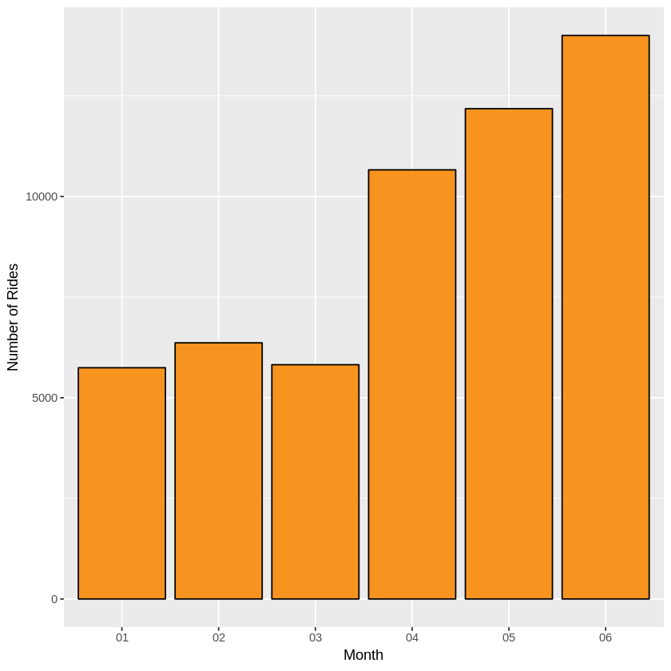

```r
qplot(x = month, data = ny, color = I('black'), fill = I('#F79420'), xlab = 'Month', ylab = 'Number of Rides') #plotting Month
```

```r
table(ny$month) ##using table to get summary info
```

```
   01    02    03    04    05    06
 5745  6364  5820 10661 12180 14000
```

##### Washington

```r
wash$month <- format(as.Date(wash$Start.Time, format="%Y-%m-%d"),"%m") #extracting month for wash dataframe
```

```r
head(wash) #verifying extraction of month and new column
```

| X | Start.Time | End.Time | Trip.Duration | Start.Station | End.Station | User.Type | month |
| --- | --- | --- | --- | --- | --- | --- | --- |
| 1621326 | 2017-06-21 08:36:34 | 2017-06-21 08:44:43 | 489.066 | 14th & Belmont St NW | 15th & K St NW | Subscriber | 06 |
| 482740 | 2017-03-11 10:40:00 | 2017-03-11 10:46:00 | 402.549 | Yuma St & Tenley Circle NW | Connecticut Ave & Yuma St NW | Subscriber | 03 |
| 1330037 | 2017-05-30 01:02:59 | 2017-05-30 01:13:37 | 637.251 | 17th St & Massachusetts Ave NW | 5th & K St NW | Subscriber | 05 |
| 665458 | 2017-04-02 07:48:35 | 2017-04-02 08:19:03 | 1827.341 | Constitution Ave & 2nd St NW/DOL | M St & Pennsylvania Ave NW | Customer | 04 |
| 1481135 | 2017-06-10 08:36:28 | 2017-06-10 09:02:17 | 1549.427 | Henry Bacon Dr & Lincoln Memorial Circle NW | Maine Ave & 7th St SW | Subscriber | 06 |
| 1148202 | 2017-05-14 07:18:18 | 2017-05-14 07:24:56 | 398.000 | 1st & K St SE | Eastern Market Metro / Pennsylvania Ave & 7th St SE | Subscriber | 05 |

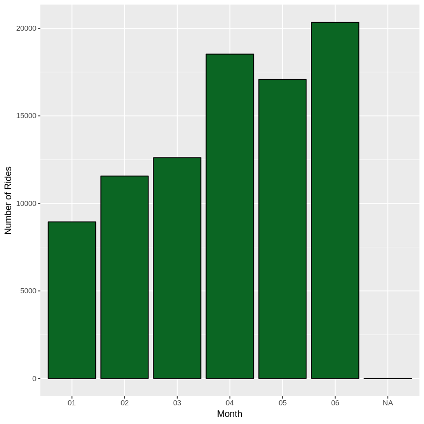

```r
qplot(x = month, data = wash, color = I('black'), fill = I('#0B6623'), xlab = 'Month', ylab = 'Number of Rides') #plotting wash dataframe for month of start.time
```

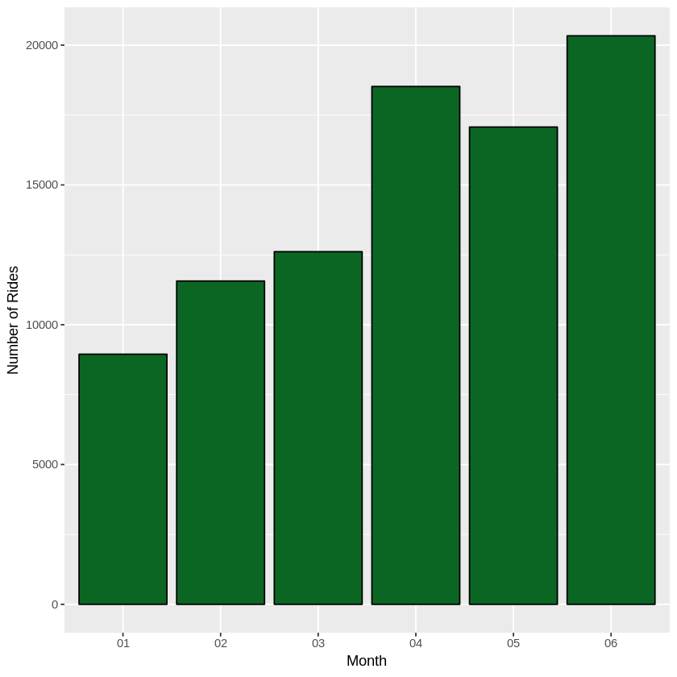

```r
qplot(x = month, data = subset(wash, !is.na(month)), color = I('black'), fill = I('#0B6623'), xlab = 'Month', ylab = 'Number of Rides') ##Removing NA column from above
```

```r
table(wash$month)
```

```
   01    02    03    04    05    06
 8946 11563 12612 18522 17072 20335
```

##### Chicago

```r
chi$month <- format(as.Date(chi$Start.Time, format="%Y-%m-%d"),"%m") #extracting month for chi dataframe
```

```r
head(chi) #verifying new column & month extracted for chi dataframe
```

| X | Start.Time | End.Time | Trip.Duration | Start.Station | End.Station | User.Type | Gender | Birth.Year | month |
| --- | --- | --- | --- | --- | --- | --- | --- | --- | --- |
| 1423854 | 2017-06-23 15:09:32 | 2017-06-23 15:14:53 | 321 | Wood St & Hubbard St | Damen Ave & Chicago Ave | Subscriber | Male | 1992 | 06 |
| 955915 | 2017-05-25 18:19:03 | 2017-05-25 18:45:53 | 1610 | Theater on the Lake | Sheffield Ave & Waveland Ave | Subscriber | Female | 1992 | 05 |
| 9031 | 2017-01-04 08:27:49 | 2017-01-04 08:34:45 | 416 | May St & Taylor St | Wood St & Taylor St | Subscriber | Male | 1981 | 01 |
| 304487 | 2017-03-06 13:49:38 | 2017-03-06 13:55:28 | 350 | Christiana Ave & Lawrence Ave | St. Louis Ave & Balmoral Ave | Subscriber | Male | 1986 | 03 |
| 45207 | 2017-01-17 14:53:07 | 2017-01-17 15:02:01 | 534 | Clark St & Randolph St | Desplaines St & Jackson Blvd | Subscriber | Male | 1975 | 01 |
| 1473887 | 2017-06-26 09:01:20 | 2017-06-26 09:11:06 | 586 | Clinton St & Washington Blvd | Canal St & Taylor St | Subscriber | Male | 1990 | 06 |

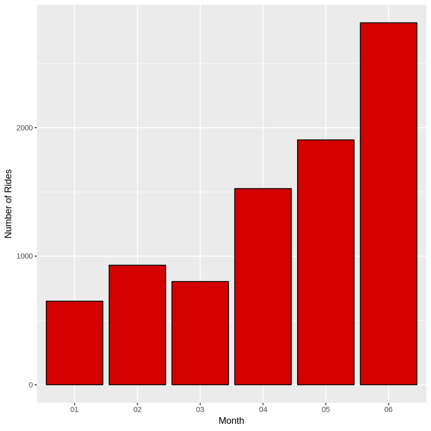

```r
qplot(x = month, data = chi, color = I('black'), fill = I('#D30000'), xlab = 'Month', ylab = 'Number of Rides') #plotting month of Start.Time for chi dataframe
```

```r
table(chi$month)
```

```
  01   02   03   04   05   06
 650  930  803 1526 1905 2816
```

In our first question, we wanted to see which Month was the most popular month for bikeshare rides across the cities of New York, Washington, and Chicago.

In New York, the most popular month was the 6th month of the year, which is June. June had a total of 14,000 rides which was 1,820 more rides than the next closest month which was May with 12,180 rides.

In Washington, the most popular month was also June. Washington had a total of 20,335 rides in the month of June which was 1,813 more rides than the next closest month. The 2nd highest month for rides in Washington was April with 18,522 rides.

In Chicago, the most popular months for rides was also the month of June. The month of June in Chicago had a total of 2816 rides. The next closest month was May with 1905 rides. One thing to note is Chicago's dataset does show a much lower volume of bikeshare rides overall.

Overall, the datasets for all 3 cities(New York, Washington, & Chicago) indicate that the most popular month for bikeshare rides is June. This would suggest that the most rides would occur during the summer month of June possibly due to more favorable weather coniditions in these 3 particular cities.

### Question 2

User Info - What is the most common User Type across the 3 cities?

##### New York

```r
table(ny$User.Type) ##Getting some info on the User.Type column, looks like we have some blanks
```

```
             Customer Subscriber
       119       5558      49093
```

```r
ny["User.Type"][ny["User.Type"] == ''] <- NA ##converting the blanks in the User.Type column to NA
```

```r
table(ny$User.Type) #checking to see if conversion worked
```

```
             Customer Subscriber
         0       5558      49093
```

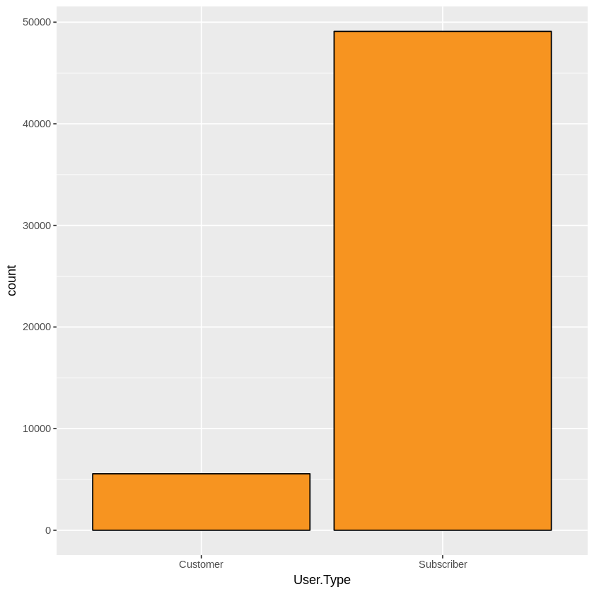

```r
ggplot(data=subset(ny, !is.na(User.Type)), aes(x=User.Type)) +
geom_bar(color = 'black', fill = '#F79420')
```

##### Washington

```r
table(wash$User.Type) ##Getting some info on the User.Type column
```

```
             Customer Subscriber
         1      23450      65600
```

```r
wash["User.Type"][wash["User.Type"] == ''] <- NA ##converting any blanks in the User.Type column to NA
```

```r
table(wash$User.Type) #checking to see if conversion worked
```

```
             Customer Subscriber
         0      23450      65600
```

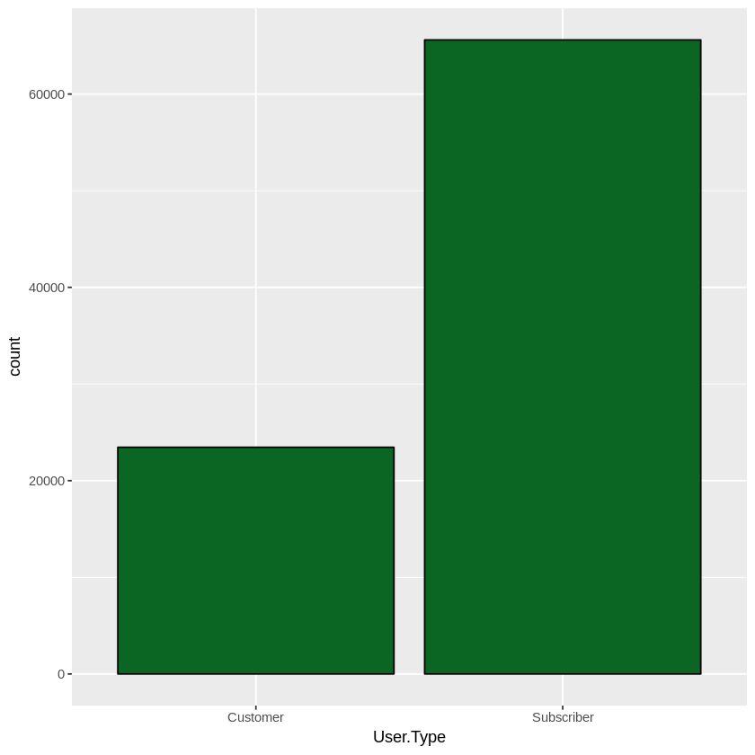

```r
ggplot(data=subset(wash, !is.na(User.Type)), aes(x=User.Type)) +
geom_bar(color = 'black', fill = '#0B6623')
```

##### Chicago

```r
table(chi$User.Type) ##Getting some info on the User.Type column
```

```
             Customer Subscriber
         1       1746       6883
```

```r
chi["User.Type"][chi["User.Type"] == ''] <- NA ##converting the blanks in the User.Type column to NA
```

```r
table(chi$User.Type) #checking to see if conversion worked
```

```
             Customer Subscriber
         0       1746       6883
```

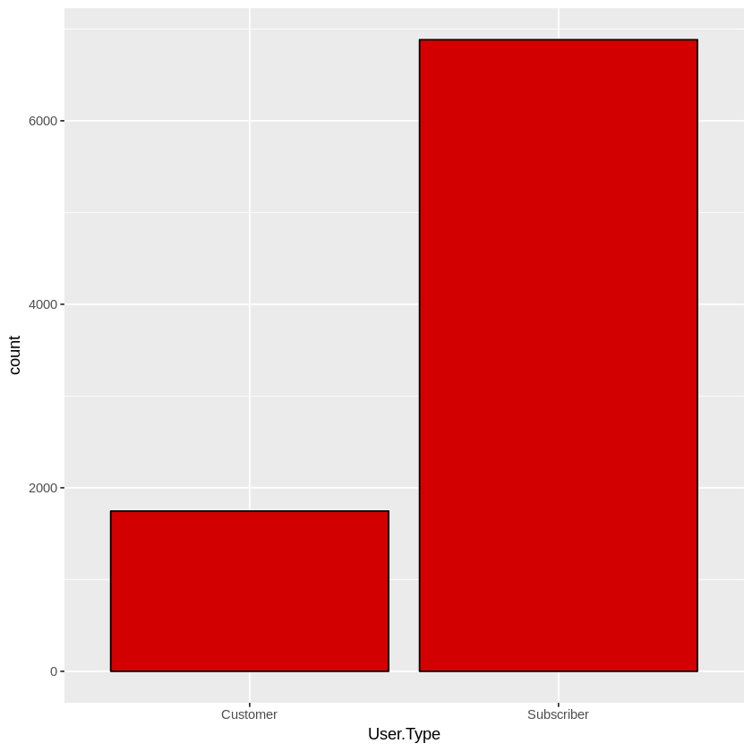

```r
ggplot(data=subset(chi, !is.na(User.Type)), aes(x=User.Type)) +
geom_bar(color = 'black', fill = '#D30000')
```

In our second question, we wanted to see which User Type was the most common for bikeshare rides across the cities of New York, Washington, and Chicago.

In New York, the most common user type was the Subscriber. The subscriber user type had a total of 49,093 while the customer user type had a total of 5,558. This would equate to a difference of 43,535 between user types in New York. About 90% of bikeshare riders in New York are subscribers.

In Washington, the most common user type was also the Subscriber. Here, the subscriber user type had a total of 65,600 while the customer user type had a total of 23,450. This would equate to a difference of 42,150 between user types in Washington. While Washington does have a higher overall customer user type the gap difference remains similar to that of New York. About 74% of bikeshare riders in Washington are subscribers.

In Chicago, the most common user type was also the Subscriber. Here, the subscriber user type had a total of 6,883 while the customer user type had a total of 1,746. This would equate to a difference of 5,137 between user types in Chicago. Again, we note Chicago's dataset does show a much lower volume of bikeshare rides overall in the city. Nonetheless, about 80% of Chicago's bikeshare rides are from subscribers.

Overall, the datasets for all 3 cities(New York, Washington, & Chicago) indicate that an overwhelming majority of bikeshare rides are utilized by the 'Subscriber' user type. This is reinforced by the data which shows each city having at least 74% of their total bikeshare rides come from subscribers over any other user type.

### Question 3

User Info - What gender type is the most common for the bikeshare data across the cities of New York & Chicago?

- Note: Gender data is not available for the city of Washington

```r
names(ny)
```

1. 'X'

2. 'Start.Time'

3. 'End.Time'

4. 'Trip.Duration'

5. 'Start.Station'

6. 'End.Station'

7. 'User.Type'

8. 'Gender'

9. 'Birth.Year'

10. 'month'

```r
names(wash) ##showing NO 'Gender' column in wash dataset
```

1. 'X'

2. 'Start.Time'

3. 'End.Time'

4. 'Trip.Duration'

5. 'Start.Station'

6. 'End.Station'

7. 'User.Type'

8. 'month'

```r
names(chi)
```

1. 'X'

2. 'Start.Time'

3. 'End.Time'

4. 'Trip.Duration'

5. 'Start.Station'

6. 'End.Station'

7. 'User.Type'

8. 'Gender'

9. 'Birth.Year'

10. 'month'

##### New York

```r
by(ny$User.Type, ny$Gender, summary)
```

```
ny$Gender:
             Customer Subscriber       NA's
         0       4743        664          3
------------------------------------------------------------
ny$Gender: Female
             Customer Subscriber       NA's
         0        324      11804         31
------------------------------------------------------------
ny$Gender: Male
             Customer Subscriber       NA's
         0        491      36625         85
```

```r
ny["Gender"][ny["Gender"] == ''] <- NA ##converting the blanks in the Gender column to NA
```

```r
by(ny$User.Type, ny$Gender, summary)
```

```
ny$Gender:
NULL
------------------------------------------------------------
ny$Gender: Female
             Customer Subscriber       NA's
         0        324      11804         31
------------------------------------------------------------
ny$Gender: Male
             Customer Subscriber       NA's
         0        491      36625         85
```

```r
ny <- na.omit(ny) ##Omit the NAs
```

```r
by(ny$User.Type, ny$Gender, summary)
```

```
ny$Gender:
NULL
------------------------------------------------------------
ny$Gender: Female
             Customer Subscriber
         0        324      11803
------------------------------------------------------------
ny$Gender: Male
             Customer Subscriber
         0        491      36625
```

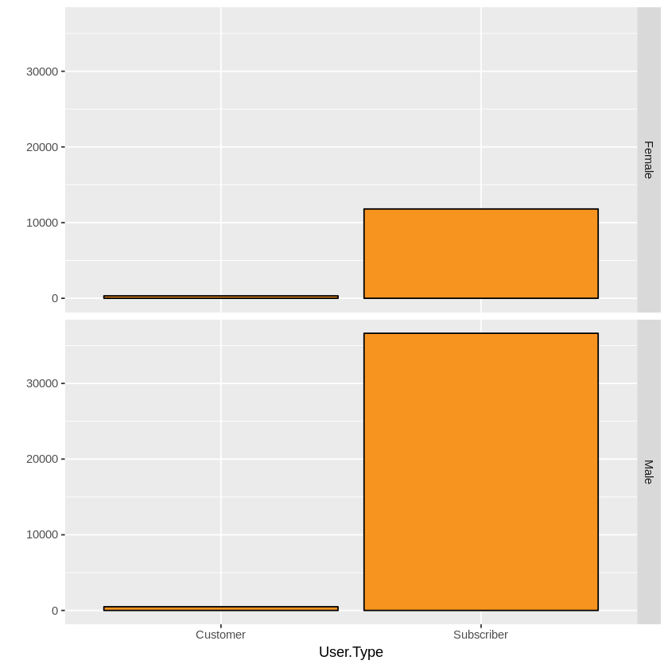

```r
qplot(x = User.Type, data = ny, color = I('black'), fill = I('#F79420')) +
    facet_grid(Gender~.)
```

##### Chicago

```r
by(chi$User.Type, chi$Gender, summary)
```

```
chi$Gender:
             Customer Subscriber       NA's
         0       1746          1          1
------------------------------------------------------------
chi$Gender: Female
             Customer Subscriber
         0          0       1723
------------------------------------------------------------
chi$Gender: Male
             Customer Subscriber
         0          0       5159
```

```r
chi["Gender"][chi["Gender"] == ''] <- NA ##converting the blanks in the Gender column to NA
```

```r
by(chi$User.Type, chi$Gender, summary)
```

```
chi$Gender:
NULL
------------------------------------------------------------
chi$Gender: Female
             Customer Subscriber
         0          0       1723
------------------------------------------------------------
chi$Gender: Male
             Customer Subscriber
         0          0       5159
```

```r
chi <- na.omit(chi) ##Omit the NAs
```

```r
by(chi$User.Type, chi$Gender, summary)
```

```
chi$Gender:
NULL
------------------------------------------------------------
chi$Gender: Female
             Customer Subscriber
         0          0       1723
------------------------------------------------------------
chi$Gender: Male
             Customer Subscriber
         0          0       5159
```

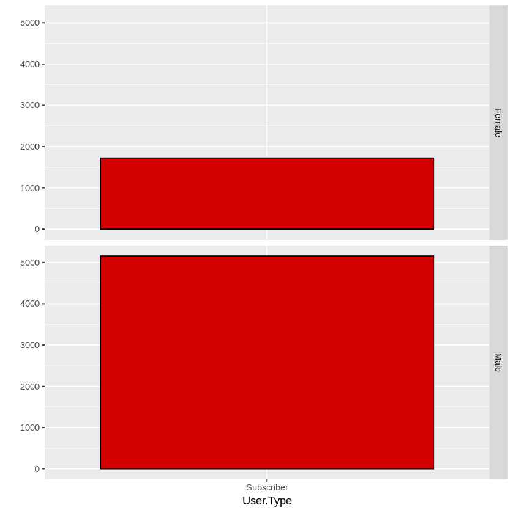

```r
qplot(x = User.Type, data = chi, color = I('black'), fill = I('#D30000')) +
    facet_grid(Gender~.)
```

In our third and final question, we wanted to see what the makeup was of Gender for each of the User Types for bikeshare rides across the cities of New York and Chicago. The city of Washington did not contain a gender column for us to analyze.

## Finishing Up

> Congratulations! You have reached the end of the Explore Bikeshare Data Project.

```r
system('python -m nbconvert Explore_bikeshare_data.ipynb')
```